# Practical Machine Learning: Course Project

Eugenio Del Prete

Saturday, September 20, 2014

### 1. Introduction to data

Using devices such as *Jawbone Up*, *Nike FuelBand*, and *Fitbit*, it is now possible to collect a large amount of data about personal activity relatively inexpensively. These type of devices are part of the quantified self movement - a group of enthusiasts who take measurements about themselves regularly to improve their health, to find patterns in their behavior, or because they are tech geeks. One thing that people regularly do is quantify how much of a particular activity they do, but they rarely quantify how well they do it. In this project, our goal will be to use data from accelerometers on the belt, forearm, arm, and dumbell of 6 participants. They were asked to perform barbell lifts correctly and incorrectly in 5 different ways: class A represents the right way, classes B,C,D,E the wrong ones. More information is available from the website [here](http://groupware.les.inf.puc-rio.br/har). Moreover, data are divided in a [training set](https://d396qusza40orc.cloudfront.net/predmachlearn/pml-training.csv) and a [testing set](https://d396qusza40orc.cloudfront.net/predmachlearn/pml-testing.csv), manually downloaded from the previous links.

### 2. Brief workflow

- Data have been manually downloaded
- Data have been pre-processed:
  - adjusting NA values and eliminating columns with only NA values
  - erasing columns that are useless for prediction
- Random Forest algorithm has been used to create a model
- Confusion matrices and accuracies have been showed to explain the model
- The model has been used to make a prediction on a test set
- An appendix shows:
  - another model calculated just one time
  - a variable importance plot for the previous model

### 3. Pre-processing data

After having manually downloaded data and put them in the working folder, they have been loaded in the global environment, with a clear choice about NA elements:

```r
train_data <- read.csv("pml-training.csv",na.strings=c("NA",""))
test_data <- read.csv("pml-testing.csv",na.strings=c("NA",""))
```

and it’s possible to see the first has 19622 observations, the second has 20 observations, both with 160 variables, some of them really useless because of NAs prensence. Making a control, it’s clear only 60 variables haven’t NAs (first column of the tables), so the others must be erased for a correct prediction:

```r
# for train_data
na_train <- sapply(train_data, function(x) {sum(is.na(x))})
table(na_train)
```

```
## na_train
##     0 19216
##    60   100
```

```r
no_col_train <- colSums(is.na(train_data)) == 19216
train_data_eff <- train_data[!no_col_train]
sum(is.na(train_data_eff))
```

```
## [1] 0
```

```r
# for test_data
na_test <- sapply(test_data, function(x) {sum(is.na(x))})
table(na_test)
```

```
## na_test
##   0  20
##  60 100
```

```r
no_col_test <- colSums(is.na(test_data)) == 20
test_data_eff <- test_data[!no_col_test]
sum(is.na(test_data_eff))
```

```
## [1] 0
```

```r
train_data_eff <- train_data_eff[,c(7:60)]
test_data_eff <- test_data_eff[,c(7:60)]
```

### 4. Building and evaluating model

At first, it has been loaded *caret* package and it has been created a partition from **train_data_eff**:

```r
library(caret)
in_train<- createDataPartition(y = train_data_eff$classe,p = 0.7,list = FALSE)
tr <- train_data_eff[in_train, ]
ts <- train_data_eff[-in_train, ]
```

Then, it has been chosen Random Forest machine learning algorithm with *randomForest* package (*n.b. The comment lines indicate that it has been tried an algorithm with 4-fold cross validation, but the system has crushed after a long computing time, so an alternative method has been found*):

```r
library(randomForest)
# model <- train(classe ~ ., data = tr, method = "rf", prox = TRUE,
#                trControl = trainControl(method = "cv", number = 4)

model <- randomForest(classe~.,data = tr)
train_predict <- predict(model,tr)
test_predict <- predict(model,ts)
confusionMatrix(train_predict,tr$classe)
```

```
## Confusion Matrix and Statistics
##
##           Reference
## Prediction    A    B    C    D    E
##          A 3906    0    0    0    0
##          B    0 2658    0    0    0
##          C    0    0 2396    0    0
##          D    0    0    0 2252    0
##          E    0    0    0    0 2525
##
## Overall Statistics
##
##                Accuracy : 1
##                  95% CI : (1, 1)
##     No Information Rate : 0.284
##     P-Value [Acc > NIR] : <2e-16
##
##                   Kappa : 1
##  Mcnemar's Test P-Value : NA
##
## Statistics by Class:
##
##                      Class: A Class: B Class: C Class: D Class: E
## Sensitivity             1.000    1.000    1.000    1.000    1.000
## Specificity             1.000    1.000    1.000    1.000    1.000
## Pos Pred Value          1.000    1.000    1.000    1.000    1.000
## Neg Pred Value          1.000    1.000    1.000    1.000    1.000
## Prevalence              0.284    0.193    0.174    0.164    0.184
## Detection Rate          0.284    0.193    0.174    0.164    0.184
## Detection Prevalence    0.284    0.193    0.174    0.164    0.184
## Balanced Accuracy       1.000    1.000    1.000    1.000    1.000
```

```r
confusionMatrix(test_predict,ts$classe)
```

```
## Confusion Matrix and Statistics
##
##           Reference
## Prediction    A    B    C    D    E
##          A 1674    1    0    0    0
##          B    0 1137    3    0    0
##          C    0    1 1022    3    0
##          D    0    0    1  961    1
##          E    0    0    0    0 1081
##
## Overall Statistics
##
##                Accuracy : 0.998
##                  95% CI : (0.997, 0.999)
##     No Information Rate : 0.284
##     P-Value [Acc > NIR] : <2e-16
##
##                   Kappa : 0.998
##  Mcnemar's Test P-Value : NA
##
## Statistics by Class:
##
##                      Class: A Class: B Class: C Class: D Class: E
## Sensitivity             1.000    0.998    0.996    0.997    0.999
## Specificity             1.000    0.999    0.999    1.000    1.000
## Pos Pred Value          0.999    0.997    0.996    0.998    1.000
## Neg Pred Value          1.000    1.000    0.999    0.999    1.000
## Prevalence              0.284    0.194    0.174    0.164    0.184
## Detection Rate          0.284    0.193    0.174    0.163    0.184
## Detection Prevalence    0.285    0.194    0.174    0.164    0.184
## Balanced Accuracy       1.000    0.999    0.998    0.998    1.000
```

### 5. Prediction

Using the previous model to make a prediction on **test_data_eff**, it has been obtained:

```r
answers <- as.character(predict(model,test_data_eff))
answers
```

```
##  [1] "B" "A" "B" "A" "A" "E" "D" "B" "A" "A" "B" "C" "B" "A" "E" "E" "A"
## [18] "B" "B" "B"
```

a character array passed to the function in this [page](https://class.coursera.org/predmachlearn-005/assignment/view?assignment_id=5), in order to know if the results are correct (yes, they are!).

### 6. Appendix

Some problems have emerged because of a long computing time in calculating model, but with only **one try**, it has been possible to show another example that gives the same result for the previous prediction (**file .rds is available in GitHub repository**):

```r
# model2 <- train(classe ~ ., data = train_data_eff, method = "rf")
# saveRDS(model2,"model2.rds")

model2 <- readRDS("model2.rds")
train_predict2 <- predict(model2,tr)
test_predict2 <- predict(model2,ts)
confusionMatrix(train_predict2,tr$classe)
```

```
## Confusion Matrix and Statistics
##
##           Reference
## Prediction    A    B    C    D    E
##          A 3906    0    0    0    0
##          B    0 2658    0    0    0
##          C    0    0 2396    0    0
##          D    0    0    0 2252    0
##          E    0    0    0    0 2525
##
## Overall Statistics
##
##                Accuracy : 1
##                  95% CI : (1, 1)
##     No Information Rate : 0.284
##     P-Value [Acc > NIR] : <2e-16
##
##                   Kappa : 1
##  Mcnemar's Test P-Value : NA
##
## Statistics by Class:
##
##                      Class: A Class: B Class: C Class: D Class: E
## Sensitivity             1.000    1.000    1.000    1.000    1.000
## Specificity             1.000    1.000    1.000    1.000    1.000
## Pos Pred Value          1.000    1.000    1.000    1.000    1.000
## Neg Pred Value          1.000    1.000    1.000    1.000    1.000
## Prevalence              0.284    0.193    0.174    0.164    0.184
## Detection Rate          0.284    0.193    0.174    0.164    0.184
## Detection Prevalence    0.284    0.193    0.174    0.164    0.184
## Balanced Accuracy       1.000    1.000    1.000    1.000    1.000
```

```r
confusionMatrix(test_predict2,ts$classe)
```

```
## Confusion Matrix and Statistics
##
##           Reference
## Prediction    A    B    C    D    E
##          A 1674    0    0    0    0
##          B    0 1139    0    0    0
##          C    0    0 1026    0    0
##          D    0    0    0  964    0
##          E    0    0    0    0 1082
##
## Overall Statistics
##
##                Accuracy : 1
##                  95% CI : (0.999, 1)
##     No Information Rate : 0.284
##     P-Value [Acc > NIR] : <2e-16
##
##                   Kappa : 1
##  Mcnemar's Test P-Value : NA
##
## Statistics by Class:
##
##                      Class: A Class: B Class: C Class: D Class: E
## Sensitivity             1.000    1.000    1.000    1.000    1.000
## Specificity             1.000    1.000    1.000    1.000    1.000
## Pos Pred Value          1.000    1.000    1.000    1.000    1.000
## Neg Pred Value          1.000    1.000    1.000    1.000    1.000
## Prevalence              0.284    0.194    0.174    0.164    0.184
## Detection Rate          0.284    0.194    0.174    0.164    0.184
## Detection Prevalence    0.284    0.194    0.174    0.164    0.184
## Balanced Accuracy       1.000    1.000    1.000    1.000    1.000
```

```r
answers2 <- as.character(predict(model2,test_data_eff))
answers2
```

```
##  [1] "B" "A" "B" "A" "A" "E" "D" "B" "A" "A" "B" "C" "B" "A" "E" "E" "A"
## [18] "B" "B" "B"
```

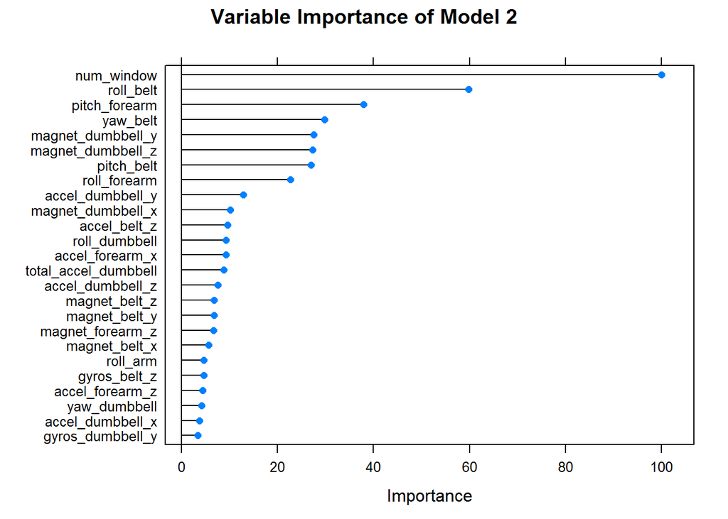

```r
var_imp <- varImp(model2)
plot(var_imp, main = "Variable Importance of Model 2", top = 25)
```

where only 8-9 variables seem to be really explanatory for the model 2 and following prediction.